# Easy_Visa_Fullcode_Project

### Context:

Business communities in the United States are facing high demand for human resources, but one of the constant challenges is identifying and attracting the right talent, which is perhaps the most important element in remaining competitive. Companies in the United States look for hard-working, talented, and qualified individuals both locally as well as abroad.

The Immigration and Nationality Act (INA) of the US permits foreign workers to come to the United States to work on either a temporary or permanent basis. The act also protects US workers against adverse impacts on their wages or working conditions by ensuring US employers' compliance with statutory requirements when they hire foreign workers to fill workforce shortages. The immigration programs are administered by the Office of Foreign Labor Certification (OFLC).

OFLC processes job certification applications for employers seeking to bring foreign workers into the United States and grants certifications in those cases where employers can demonstrate that there are not sufficient US workers available to perform the work at wages that meet or exceed the wage paid for the occupation in the area of intended employment.

### Objective:

In FY 2016, the OFLC processed 775,979 employer applications for 1,699,957 positions for temporary and permanent labor certifications. This was a nine percent increase in the overall number of processed applications from the previous year. The process of reviewing every case is becoming a tedious task as the number of applicants is increasing every year.

The increasing number of applicants every year calls for a Machine Learning based solution that can help in shortlisting the candidates having higher chances of VISA approval. OFLC has hired the firm EasyVisa for data-driven solutions. You as a data scientist at EasyVisa have to analyze the data provided and, with the help of a classification model:

- Facilitate the process of visa approvals.
- Recommend a suitable profile for the applicants for whom the visa should be certified or denied based on the drivers that significantly influence the case status.

### Data Description

The data contains the different attributes of employee and the employer. The detailed data dictionary is given below.

- case_id: ID of each visa application
- continent: Information of continent the employee
- education_of_employee: Information of education of the employee
- has_job_experience: Does the employee has any job experience? Y= Yes; N = No
- requires_job_training: Does the employee require any job training? Y = Yes; N = No
- no_of_employees: Number of employees in the employer's company
- yr_of_estab: Year in which the employer's company was established
- region_of_employment: Information of foreign worker's intended region of employment in the US.
- prevailing_wage: Average wage paid to similarly employed workers in a specific occupation in the area of intended employment. The purpose of the prevailing wage is to ensure that the foreign worker is not underpaid compared to other workers offering the same or similar service in the same area of employment.
- unit_of_wage: Unit of prevailing wage. Values include Hourly, Weekly, Monthly, and Yearly.
- full_time_position: Is the position of work full-time? Y = Full Time Position; N = Part Time Position
- case_status: Flag indicating if the Visa was certified or denied

### Importing the necessary libraries

```python
%load_ext nb_black

import warnings

warnings.filterwarnings("ignore")

# Libraries to help with reading and manipulating data
import numpy as np
import pandas as pd

# Library to split data
from sklearn.model_selection import train_test_split

# libaries to help with data visualization
import matplotlib.pyplot as plt
import seaborn as sns

# Removes the limit for the number of displayed columns
pd.set_option("display.max_columns", None)
# Sets the limit for the number of displayed rows
pd.set_option("display.max_rows", 100)


# Libraries different ensemble classifiers
from sklearn.ensemble import (
    BaggingClassifier,
    RandomForestClassifier,
    AdaBoostClassifier,
    GradientBoostingClassifier,
    StackingClassifier,
)

from xgboost import XGBClassifier
from sklearn.tree import DecisionTreeClassifier

# Libraries to get different metric scores
from sklearn import metrics
from sklearn.metrics import (
    confusion_matrix,
    accuracy_score,
    precision_score,
    recall_score,
    f1_score,
)

# To tune different models
from sklearn.model_selection import GridSearchCV
```

### Importing the dataset

```python
visa = pd.read_csv(
    "C:\\Users\\USER\Downloads\\EasyVisa.csv"
)  # import the dataset used for the analysis and building the model
```

```python
data = visa.copy()  # copy the dataset into another variable
```

### Overview of the dataset

```python
data.head()  # view the first five rows of the dataset
```

|  | case_id | continent | education_of_employee | has_job_experience | requires_job_training | no_of_employees | yr_of_estab | region_of_employment | prevailing_wage | unit_of_wage | full_time_position | case_status |
| --- | --- | --- | --- | --- | --- | --- | --- | --- | --- | --- | --- | --- |
| 0 | EZYV01 | Asia | High School | N | N | 14513 | 2007 | West | 592.2029 | Hour | Y | Denied |
| 1 | EZYV02 | Asia | Master's | Y | N | 2412 | 2002 | Northeast | 83425.6500 | Year | Y | Certified |
| 2 | EZYV03 | Asia | Bachelor's | N | Y | 44444 | 2008 | West | 122996.8600 | Year | Y | Denied |
| 3 | EZYV04 | Asia | Bachelor's | N | N | 98 | 1897 | West | 83434.0300 | Year | Y | Denied |
| 4 | EZYV05 | Africa | Master's | Y | N | 1082 | 2005 | South | 149907.3900 | Year | Y | Certified |

```python
data.tail()  # view the last five rows of the dataset
```

|  | case_id | continent | education_of_employee | has_job_experience | requires_job_training | no_of_employees | yr_of_estab | region_of_employment | prevailing_wage | unit_of_wage | full_time_position | case_status |
| --- | --- | --- | --- | --- | --- | --- | --- | --- | --- | --- | --- | --- |
| 25475 | EZYV25476 | Asia | Bachelor's | Y | Y | 2601 | 2008 | South | 77092.57 | Year | Y | Certified |
| 25476 | EZYV25477 | Asia | High School | Y | N | 3274 | 2006 | Northeast | 279174.79 | Year | Y | Certified |
| 25477 | EZYV25478 | Asia | Master's | Y | N | 1121 | 1910 | South | 146298.85 | Year | N | Certified |
| 25478 | EZYV25479 | Asia | Master's | Y | Y | 1918 | 1887 | West | 86154.77 | Year | Y | Certified |
| 25479 | EZYV25480 | Asia | Bachelor's | Y | N | 3195 | 1960 | Midwest | 70876.91 | Year | Y | Certified |

```python
data.shape  # view the dimensions of the dataset
```

```
(25480, 12)
```

There are 25480 rows and 12 columns in the dataset.

```python
data.info()  # view the datatypes of the columns in the dataset
```

```
<class 'pandas.core.frame.DataFrame'>
RangeIndex: 25480 entries, 0 to 25479
Data columns (total 12 columns):
 #   Column                 Non-Null Count  Dtype
---  ------                 --------------  -----
 0   case_id                25480 non-null  object
 1   continent              25480 non-null  object
 2   education_of_employee  25480 non-null  object
 3   has_job_experience     25480 non-null  object
 4   requires_job_training  25480 non-null  object
 5   no_of_employees        25480 non-null  int64
 6   yr_of_estab            25480 non-null  int64
 7   region_of_employment   25480 non-null  object
 8   prevailing_wage        25480 non-null  float64
 9   unit_of_wage           25480 non-null  object
 10  full_time_position     25480 non-null  object
 11  case_status            25480 non-null  object
dtypes: float64(1), int64(2), object(9)
memory usage: 2.3+ MB
```

- There are nine (9) object columns; two (2) integer columns and one (1) float column.
- The dataset uses about 2.3 MB of memory

```python
data.duplicated().sum()  # check for duplicate values in the dataset
```

```
0
```

There are no duplicate values in the dataset.

```python
data.isna().sum()  # check for missing values in the dataset
```

```
case_id                  0
continent                0
education_of_employee    0
has_job_experience       0
requires_job_training    0
no_of_employees          0
yr_of_estab              0
region_of_employment     0
prevailing_wage          0
unit_of_wage             0
full_time_position       0
case_status              0
dtype: int64
```

### Exploratory Analysis

```python
data.describe().T  # check statistical summary of numeric columns of the dataset
```

|  | count | mean | std | min | 25% | 50% | 75% | max |
| --- | --- | --- | --- | --- | --- | --- | --- | --- |
| no_of_employees | 25480.0 | 5667.043210 | 22877.928848 | -26.0000 | 1022.00 | 2109.00 | 3504.0000 | 602069.00 |
| yr_of_estab | 25480.0 | 1979.409929 | 42.366929 | 1800.0000 | 1976.00 | 1997.00 | 2005.0000 | 2016.00 |
| prevailing_wage | 25480.0 | 74455.814592 | 52815.942327 | 2.1367 | 34015.48 | 70308.21 | 107735.5125 | 319210.27 |

- The average number of employees is 5667 with a mean prevailing wage of 74,455.80
- 50% of employees earn about 70,308.20 and the highest earner receives about 319,210.30.
- The lowest wage received by an employee is 2.14. This is ostensibly unrealistic and could be a mistaken input. Further verification would be required.

#### Fixing rows with negative values

```python
data.loc[
    data["no_of_employees"] < 0
].shape  # check negative values in the number of employees column
```

```
(33, 12)
```

There are 33 rows with negative values in the number of employees column.

```python
# We will consider the absolute values for the negative values in the number of employees column
data["no_of_employees"] = abs(
    data["no_of_employees"]
)  # function to convert the negative values to positive values
```

```python
data.loc[
    data["no_of_employees"] < 0
].shape  # number of rows with negative values after conversion
```

```
(0, 12)
```

- There are no remaining rows with negative values in the number of employees column.

#### Check unique count of categorical variables

```python
# list of categorical variables in the dataset
cat_col = list(data.select_dtypes("object").columns)

# Print number of count of each unique value in each column
for column in cat_col:
    print(data[column].value_counts())
    print("-" * 50)
```

```
EZYV01       1
EZYV16995    1
EZYV16993    1
EZYV16992    1
EZYV16991    1
            ..
EZYV8492     1
EZYV8491     1
EZYV8490     1
EZYV8489     1
EZYV25480    1
Name: case_id, Length: 25480, dtype: int64
--------------------------------------------------
Asia             16861
Europe            3732
North America     3292
South America      852
Africa             551
Oceania            192
Name: continent, dtype: int64
--------------------------------------------------
Bachelor's     10234
Master's        9634
High School     3420
Doctorate       2192
Name: education_of_employee, dtype: int64
--------------------------------------------------
Y    14802
N    10678
Name: has_job_experience, dtype: int64
--------------------------------------------------
N    22525
Y     2955
Name: requires_job_training, dtype: int64
--------------------------------------------------
Northeast    7195
South        7017
West         6586
Midwest      4307
Island        375
Name: region_of_employment, dtype: int64
--------------------------------------------------
Year     22962
Hour      2157
Week       272
Month       89
Name: unit_of_wage, dtype: int64
--------------------------------------------------
Y    22773
N     2707
Name: full_time_position, dtype: int64
--------------------------------------------------
Certified    17018
Denied        8462
Name: case_status, dtype: int64
--------------------------------------------------
```

- There is one unique id for the visa application for each employee.
- Asia, Europe and North America respectively, are the top three continents with the most number of employees.
- 10.234 have a bachelors degree. This is closely followed by 9,634 employees with a masters degree.
- There are more employees with some job experience than those who do not have any.
- There are more employees who do not require any job training than those who do.
- Very few employees desire to work in the island regions. The choice areas are the Northeast and the South respectively.
- 22,962 of the employees use the annual unit of wage payment while 89 use the monthly option.
- 22,773 employees have a full-time position while only 2,707 have a part-time job.
- 17,018 employees have a certified visa and 8,462 were denied one.

```python
data.drop(
    ["case_id"], axis=1, inplace=True
)  # drop 'case_id' column from the data as it does not add any value to the outcome of the dependent variable
```

```python
data.info()  # concise summary of the dataframe
```

```
<class 'pandas.core.frame.DataFrame'>
RangeIndex: 25480 entries, 0 to 25479
Data columns (total 11 columns):
 #   Column                 Non-Null Count  Dtype
---  ------                 --------------  -----
 0   continent              25480 non-null  object
 1   education_of_employee  25480 non-null  object
 2   has_job_experience     25480 non-null  object
 3   requires_job_training  25480 non-null  object
 4   no_of_employees        25480 non-null  int64
 5   yr_of_estab            25480 non-null  int64
 6   region_of_employment   25480 non-null  object
 7   prevailing_wage        25480 non-null  float64
 8   unit_of_wage           25480 non-null  object
 9   full_time_position     25480 non-null  object
 10  case_status            25480 non-null  object
dtypes: float64(1), int64(2), object(8)
memory usage: 2.1+ MB
```

- The case_id column has been dropped from the dataframe.
- Consequently, the memory size has reduced to about 2.1 MB.

### Univariate Analysis

```python
# function to plot histogram and boxplot of the numeric variables
def histogram_boxplot(data, feature, figsize=(15, 10), kde=False, bins=None):
    """
    Boxplot and histogram combined

    data: dataframe
    feature: dataframe column
    figsize: size of figure (default (15,10))
    kde: whether to show the density curve (default False)
    bins: number of bins for histogram (default None)
    """
    f2, (ax_box2, ax_hist2) = plt.subplots(
        nrows=2,  # Number of rows of the subplot grid= 2
        sharex=True,  # x-axis will be shared among all subplots
        gridspec_kw={"height_ratios": (0.25, 0.75)},
        figsize=figsize,
    )  # creating the 2 subplots
    sns.boxplot(
        data=data, x=feature, ax=ax_box2, showmeans=True, color="violet"
    )  # boxplot will be created and a triangle will indicate the mean value of the column
    sns.histplot(
        data=data, x=feature, kde=kde, ax=ax_hist2, bins=bins
    ) if bins else sns.histplot(
        data=data, x=feature, kde=kde, ax=ax_hist2
    )  # For histogram
    ax_hist2.axvline(
        data[feature].mean(), color="green", linestyle="--"
    )  # Add mean to the histogram
    ax_hist2.axvline(
        data[feature].median(), color="black", linestyle="-"
    )  # Add median to the histogram
```

#### Number of employees

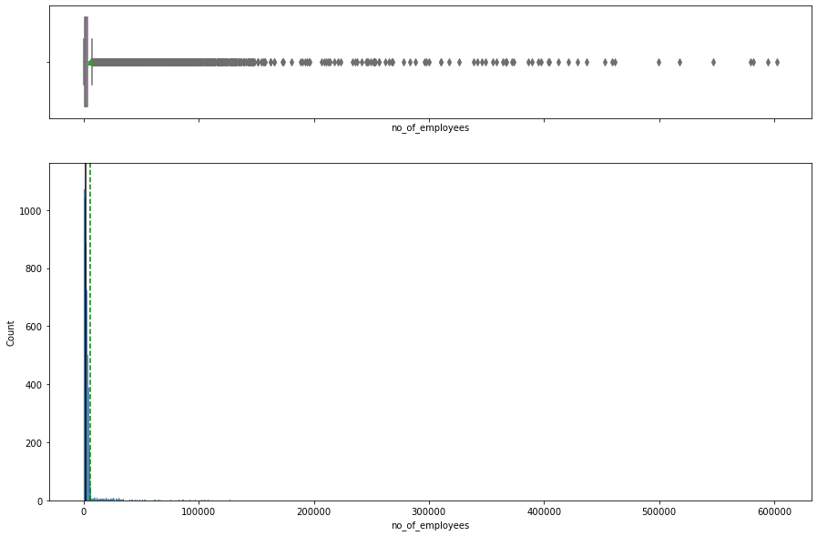

```python
histogram_boxplot(
    data, "no_of_employees"
)  # create histogram_boxplot for number of employees
```

- The distribution is right skewed with many outliers on the right whisker.
- The graph shows companies with over 600,000 employees. This could be from the corporate giants.

#### Prevailing wage

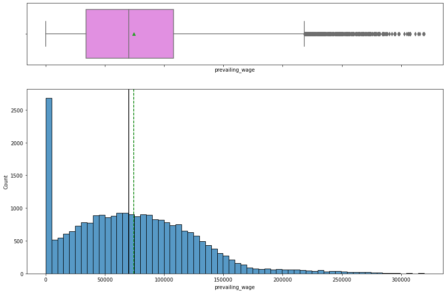

```python
histogram_boxplot(
    data, "prevailing_wage"
)  # create histogram_boxplot for prevailing wage
```

- The boxplot is slightly right skewed due to a small difference between the greater mean and median value.
- 50% of employees earn less than the average prevailing wage.
- The presence of outliers indicate employees who earn significantly more than the statistical maximum. Perhaps these employees are in top level positions hence the indicated values.

```python
# observations which have less than 100 prevailing wage
data.loc[data["prevailing_wage"] < 100].shape  # rows with less than 100 prevailing wage
```

```
(176, 11)
```

- There are 176 rows with prevailing wage less than 100.

```python
data.loc[
    data["prevailing_wage"] < 100, "unit_of_wage"
].value_counts()  # count of values in the mentioned column
```

```
Hour    176
Name: unit_of_wage, dtype: int64
```

- The employees with prevailing wage less than 100 are paid by the hour.

```python
# function to create labeled barplots for categorical variables


def labeled_barplot(data, feature, perc=False, n=None):
    """
    Barplot with percentage at the top

    data: dataframe
    feature: dataframe column
    perc: whether to display percentages instead of count (default is False)
    n: displays the top n category levels (default is None, i.e., display all levels)
    """

    total = len(data[feature])  # length of the column
    count = data[feature].nunique()
    if n is None:
        plt.figure(figsize=(count + 2, 6))
    else:
        plt.figure(figsize=(n + 2, 6))

    plt.xticks(rotation=90, fontsize=15)
    ax = sns.countplot(
        data=data,
        x=feature,
        palette="Paired",
        order=data[feature].value_counts().index[:n],
    )

    for p in ax.patches:
        if perc == True:
            label = "{:.1f}%".format(
                100 * p.get_height() / total
            )  # percentage of each class of the category
        else:
            label = p.get_height()  # count of each level of the category

        x = p.get_x() + p.get_width() / 2  # width of the plot
        y = p.get_height()  # height of the plot

        ax.annotate(
            label,
            (x, y),
            ha="center",
            va="center",
            size=12,
            xytext=(0, 5),
            textcoords="offset points",
        )  # annotate the percentage

    plt.show()  # show the plot
```

#### Continent

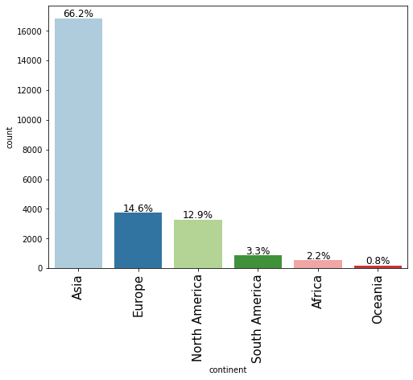

```python
labeled_barplot(data, "continent", perc=True)  # create bar plot for continent variable
```

- Asia is the dominant continent in this category with 66% of employees hailing from there.
- Oceania has less than 1% of employees and represents the continent with the least count.

#### Education of Employee

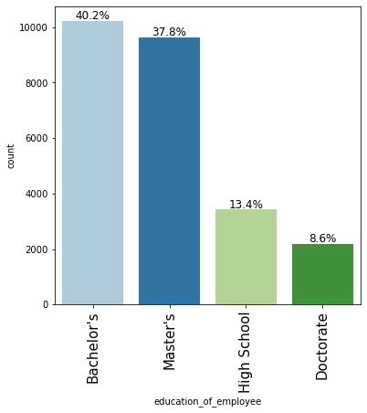

```python
labeled_barplot(
    data, "education_of_employee", perc=True
)  # create labeled_barplot for education of employee
```

- About 40% of employees have a Bachelors degree; 37.8% have a Masters degree; 13.4% a high school qualification and 8.6% a doctorate degree. However, there are more employees with a bachelors degree than those with a masters degree.
- Employees with a doctorate degree represent the least count in this category.

#### Job Experience

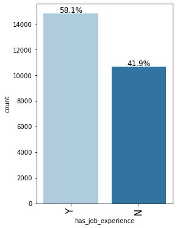

```python
labeled_barplot(
    data, "has_job_experience", perc=True
)  # create labeled_barplot for job experience
```

- More than 50% of employees have some job experience.

#### Job Training

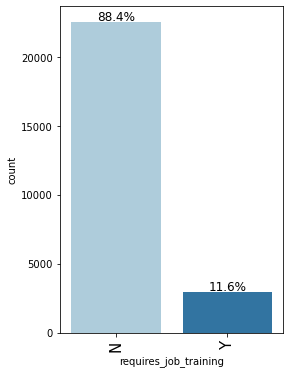

```python
labeled_barplot(
    data, "requires_job_training", perc=True
)  # create labeled_barplot for job training
```

- At least 88% of employees do not require any job training.

#### Region of Employment

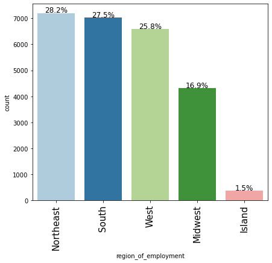

```python
labeled_barplot(
    data, "region_of_employment", perc=True
)  # create labeled_barplot for region of employment
```

- Out of the five regions under consideration, Northeast,South and West respectively represent the top three regions with the highest number of employees with more than 25% each.
- The island region has the least count with only 1.5%.

#### Unit of Wage

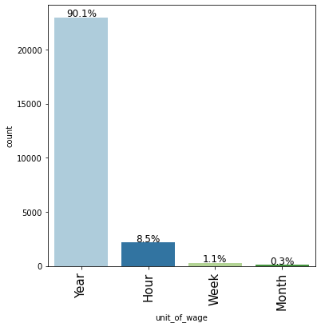

```python
labeled_barplot(
    data, "unit_of_wage", perc=True
)  # create labeled_barplot for unit of wage
```

- At least 90% of employees use the yearly unit of wage while less than 1% use the monthly option.

#### Case Status

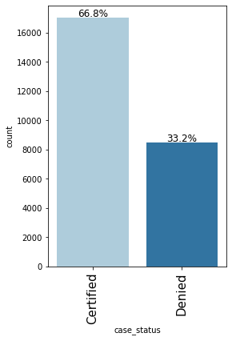

```python
labeled_barplot(
    data, "case_status", perc=True
)  # create labeled_barplot for case status
```

- More than 66% of employees have a certified visa while about 33.2% were denied one.

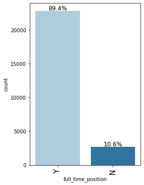

```python
labeled_barplot(
    data, "full_time_position", perc=True
)  # create labeled_barplot for full time position
```

- There are more employees in a full-time job than there are in part-time jobs.

#### Year of Establishment

```python
data["yr_of_estab"].nunique()  # unique number of values in the column
```

```
199
```

- There are 199 different establishment years of the companies that the employees work in.

```python
data["yr_of_estab"].value_counts()  # counts of the 199 different establishment years
```

```
1998    1134
2005    1051
2001    1017
2007     994
1999     870
        ...
1842       6
1846       4
1822       4
1810       3
1824       2
Name: yr_of_estab, Length: 199, dtype: int64
```

### Bivariate Analysis

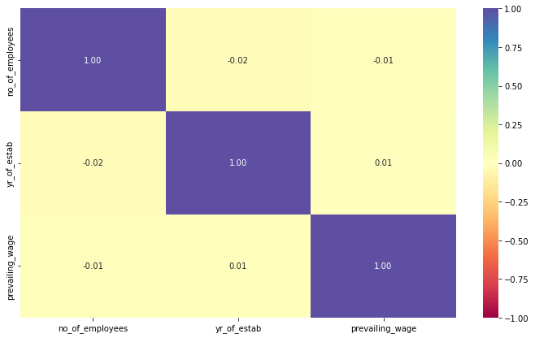

```python
cols_list = data.select_dtypes(
    include=np.number
).columns.tolist()  # create a list of numeric datatype columns

plt.figure(figsize=(12, 7))  # size configuration
sns.heatmap(
    data[cols_list].corr(), annot=True, vmin=-1, vmax=1, fmt=".2f", cmap="Spectral"
)  # correlation between the variables
plt.show()  # plot the graph
```

- The graph does not show any significant correlation between the numeric variables.

```python
### function to plot distributions wrt target


def distribution_plot_wrt_target(data, predictor, target):

    fig, axs = plt.subplots(2, 2, figsize=(12, 10))

    target_uniq = data[target].unique()

    axs[0, 0].set_title("Distribution of target for target=" + str(target_uniq[0]))
    sns.histplot(
        data=data[data[target] == target_uniq[0]],
        x=predictor,
        kde=True,
        ax=axs[0, 0],
        color="teal",
        stat="density",
    )

    axs[0, 1].set_title("Distribution of target for target=" + str(target_uniq[1]))
    sns.histplot(
        data=data[data[target] == target_uniq[1]],
        x=predictor,
        kde=True,
        ax=axs[0, 1],
        color="orange",
        stat="density",
    )

    axs[1, 0].set_title("Boxplot w.r.t target")
    sns.boxplot(data=data, x=target, y=predictor, ax=axs[1, 0], palette="gist_rainbow")

    axs[1, 1].set_title("Boxplot (without outliers) w.r.t target")
    sns.boxplot(
        data=data,
        x=target,
        y=predictor,
        ax=axs[1, 1],
        showfliers=False,
        palette="gist_rainbow",
    )

    plt.tight_layout()
    plt.show()
```

```python
# function to create stacked barplot to verify correlation between variables


def stacked_barplot(data, predictor, target):
    """
    Print the category counts and plot a stacked bar chart

    data: dataframe
    predictor: independent variable
    target: target variable
    """
    count = data[predictor].nunique()
    sorter = data[target].value_counts().index[-1]
    tab1 = pd.crosstab(data[predictor], data[target], margins=True).sort_values(
        by=sorter, ascending=False
    )
    print(tab1)
    print("-" * 120)
    tab = pd.crosstab(data[predictor], data[target], normalize="index").sort_values(
        by=sorter, ascending=False
    )
    tab.plot(kind="bar", stacked=True, figsize=(count + 5, 5))
    plt.legend(
        loc="lower left", frameon=False,
    )
    plt.legend(loc="upper left", bbox_to_anchor=(1, 1))
    plt.show()
```

#### Impact of education on visa certification.

```
case_status            Certified  Denied    All
education_of_employee
All                        17018    8462  25480
Bachelor's                  6367    3867  10234
High School                 1164    2256   3420
Master's                    7575    2059   9634
Doctorate                   1912     280   2192
------------------------------------------------------------------------------------------------------------------------
```

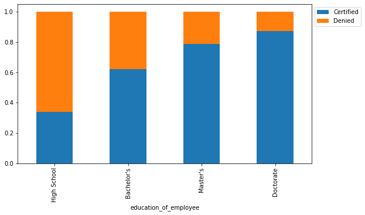

```python
stacked_barplot(data, "education_of_employee", "case_status")
```

- The distribution shows a positive correlation between the two variables.
- There is an increasing number of visa certifications per every advanced level of education.
- This allows us to make the conclusion that there is some impact of an employees level education on their chances of obtaining a certified visa.

#### The regions and their relative educational background count

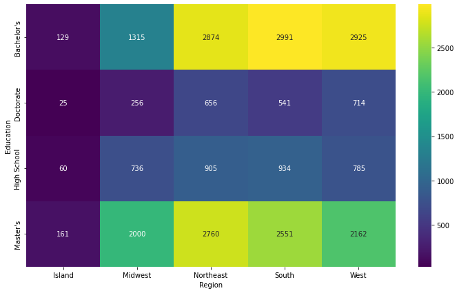

```python
plt.figure(figsize=(12, 7))  # size configurations
sns.heatmap(
    pd.crosstab(data["education_of_employee"], data["region_of_employment"]),
    annot=True,
    fmt="g",
    cmap="viridis",
)  # plot heatmap for the crosstab between education and region of employment

plt.ylabel("Education")  # label of the y- axis
plt.xlabel("Region")  # x-axis label
plt.show()  # plot graph
```

- The Northeast region has the highest number of employees with a masters degree and the island area has the least.
- The South has the most employees with a high school and Bachelor degree qualifications.
- The West have the most number of employees with doctorate degrees while the island area has the least.

#### Visa Certifications across each region

```
case_status           Certified  Denied    All
region_of_employment
All                       17018    8462  25480
Northeast                  4526    2669   7195
West                       4100    2486   6586
South                      4913    2104   7017
Midwest                    3253    1054   4307
Island                      226     149    375
------------------------------------------------------------------------------------------------------------------------
```

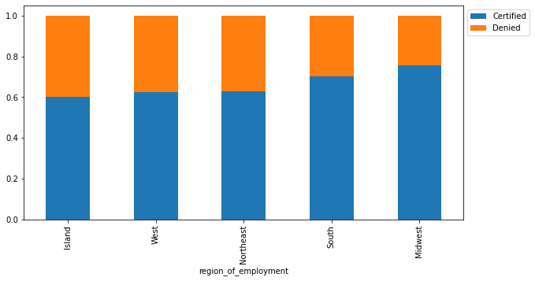

```python
stacked_barplot(
    data, "region_of_employment", "case_status"
)  # plot stacked barplot for region of employment and case status
```

- The Midwest has the most number of employees with certified visas while the Island region has the most number of employees with the most denied visas.
- The Island also has the least number of certified visas amongst the five regions.

#### The variation of the visa status across the different continents

```
case_status    Certified  Denied    All
continent
All                17018    8462  25480
Asia               11012    5849  16861
North America       2037    1255   3292
Europe              2957     775   3732
South America        493     359    852
Africa               397     154    551
Oceania              122      70    192
------------------------------------------------------------------------------------------------------------------------
```

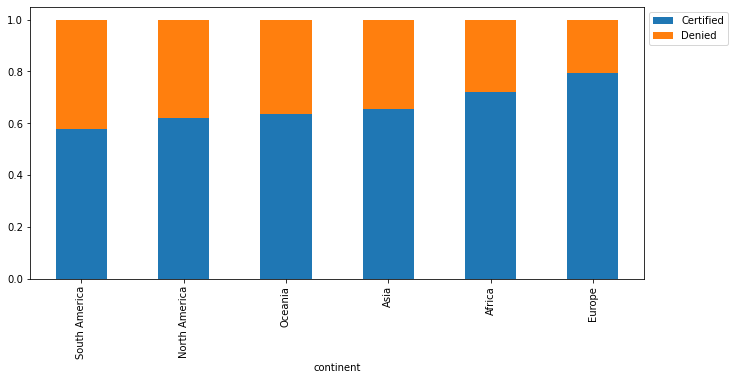

```python
stacked_barplot(
    data, "continent", "case_status"
)  # plot stacked barplot for continent and case status
```

- Europe has the most number of employees with certified visas and the least number of employees with denied visas.
- South America has the most number of employees with denied visas.

#### Is Europe's numbers due to higher level of education?

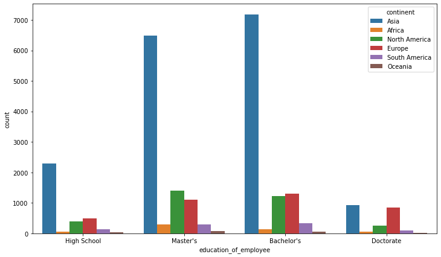

```python
plt.figure(figsize=(12, 7))  # size configurations
sns.countplot(
    data=data, x="education_of_employee", hue="continent"
)  # bar graph with relative count on various continents
plt.show()
```

- Even though Europe has more employees with certified visas, Asia has more employees with more advanced levels of education hence we cannot incisively attribute Europe's high visa certifications to advanced level of education

#### Impact of work experience on visa certification

```
case_status         Certified  Denied    All
has_job_experience
All                     17018    8462  25480
N                        5994    4684  10678
Y                       11024    3778  14802
------------------------------------------------------------------------------------------------------------------------
```

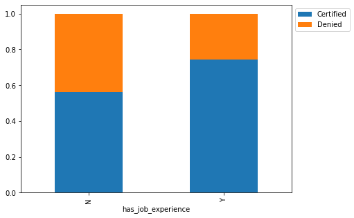

```python
stacked_barplot(
    data, "has_job_experience", "case_status"
)  # plot stacked barplot for job experience and case status
```

- The employees with some job experience have more job certifications than those that do not.
- The reverse is true for the denied visas category.
- This distribution presents the likelihood that job experience may have some impact on visa certification.

#### Do the employees who have prior work experience require any job training?

```
requires_job_training      N     Y    All
has_job_experience
All                    22525  2955  25480
N                       8988  1690  10678
Y                      13537  1265  14802
------------------------------------------------------------------------------------------------------------------------
```

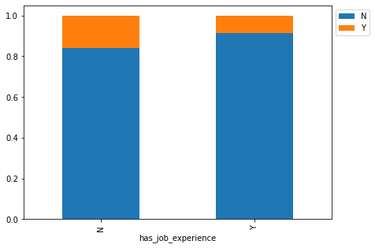

```python
stacked_barplot(
    data, "has_job_experience", "requires_job_training"
)  # plot stacked barplot for job experience and requires_job_training
```

- There are fewer employees who have some work experience who require job training compared to those that do not have any work experience.
- This indicates the likelihood that employees with no prior work experience will require some form of training.

#### The correlation between the prevailing wage and the visa status

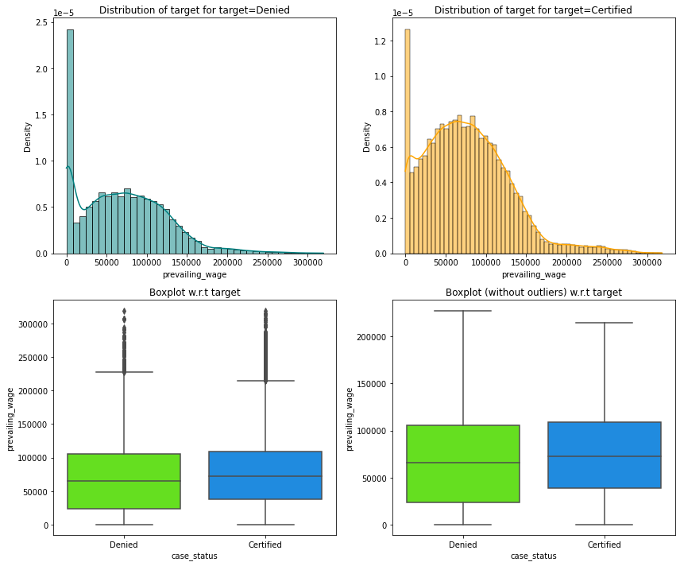

```python
distribution_plot_wrt_target(
    data, "prevailing_wage", "case_status"
)  # find distribution of prevailing wage and case status
```

- The mean salary of employees with certified visas is slightly greater than the salary of employees with denied visas. This slight difference,however, is not enough to draw a conclusion on their correlation.

#### Prevailing wage across all the regions of the US

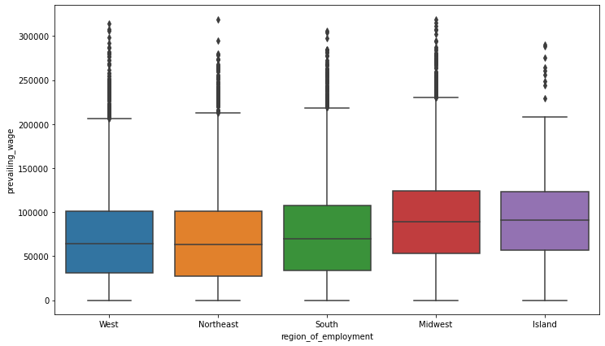

```python
plt.figure(figsize=(12, 7))  # size configurations
sns.boxplot(
    data=data, x="region_of_employment", y="prevailing_wage"
)  # create boxplot for region of employment and prevailing wage
plt.show()
```

- The Midwest and Island have the highest mean salary amongst all the different regions in the US.
- The West and Northeast also have similar values for the mean salary with the South leading with slightly greater.

#### Why Island has high mean value despite a small workforce.

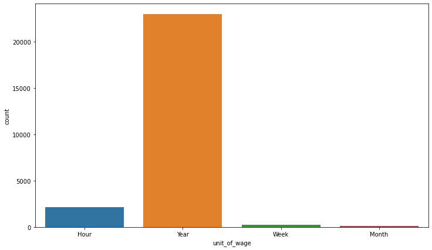

```python
plt.figure(figsize=(12, 7))  # size configurations
sns.countplot(data=data, x="unit_of_wage")  # bar graph of unit_of_wage
```

```
unit_of_wage          Hour  Month  Week   Year    All
region_of_employment
All                   2157     89   272  22962  25480
Northeast              865     29    92   6209   7195
South                  696     28    68   6225   7017
West                   432     19    77   6058   6586
Midwest                146     13    32   4116   4307
Island                  18      0     3    354    375
------------------------------------------------------------------------------------------------------------------------
```

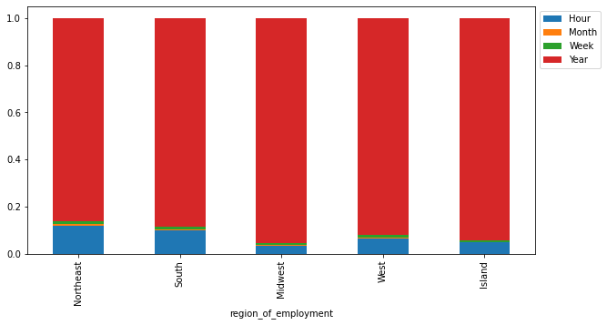

```python
stacked_barplot(
    data, "region_of_employment", "unit_of_wage"
)  # stacked barplot between region of employment and unit of wage
```

#### Impact of unit of wage on visa certification

```
case_status   Certified  Denied    All
unit_of_wage
All               17018    8462  25480
Year              16047    6915  22962
Hour                747    1410   2157
Week                169     103    272
Month                55      34     89
------------------------------------------------------------------------------------------------------------------------
```

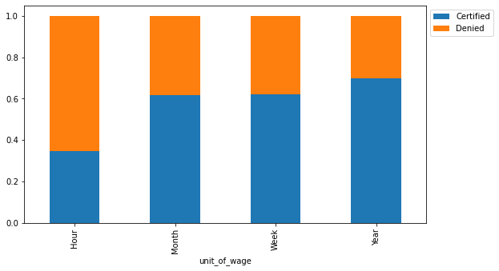

```python
stacked_barplot(
    data, "unit_of_wage", "case_status"
)  # plot stacked barplot for unit of wage and case status
```

- A normal progression to confirm an ostensible correlation between the two variables would be an increase in number of visa certifications from: hour,weekly,monthly and yearly. Although the hour and year fit the progression, there is disparity in the weekly and monthly options hence we cannot conclude an ostensible correlation between the two variables.

#### Unit of wage and Prevailing Wage

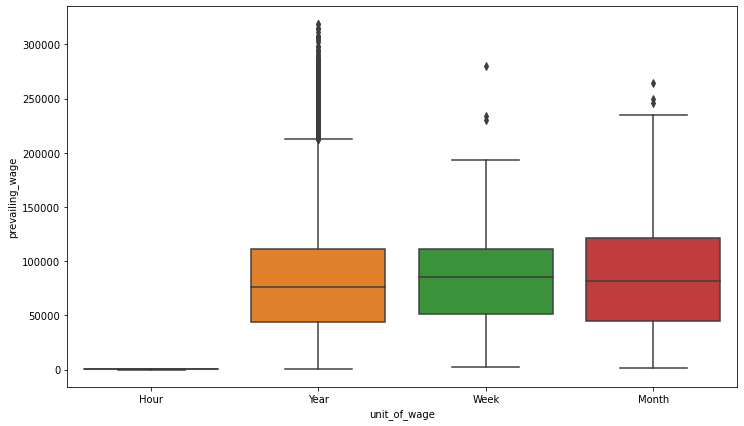

```python
plt.figure(figsize=(12, 7))  # size configurations
sns.boxplot(data=data, x="unit_of_wage", y="prevailing_wage")
# boxplot of unit of wage and prevailing wage
```

- The monthly unit of wage has the highest mean prevailing wage while the hourly has the least. However, the are significantly more outliers on the right whisker of the yearly unit of wage, indicating some very high prevaiing wage values.

#### The education demographic of the different continents per the employees.

```
education_of_employee  Bachelor's  Doctorate  High School  Master's    All
continent
All                         10234       2192         3420      9634  25480
Asia                         7168        923         2290      6480  16861
Europe                       1299        846          490      1097   3732
North America                1225        258          401      1408   3292
South America                 333         89          137       293    852
Africa                        143         54           66       288    551
Oceania                        66         22           36        68    192
------------------------------------------------------------------------------------------------------------------------
```

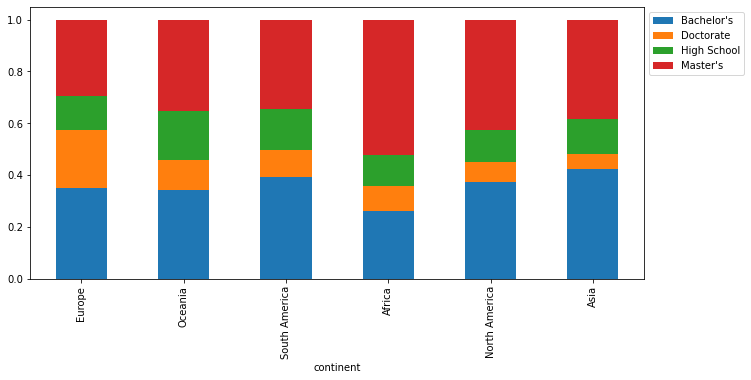

```python
stacked_barplot(data, "continent", "education_of_employee")
```

- Even though Africa has the least number of employees with a Bachelor's degree, it has the most employees with a Master's degree.
- Europe has the most employees with doctorate degrees while Asia has the least.
- Oceania has the most nummber of employees with high school qualification.

#### Distribution of number of employees from each continent

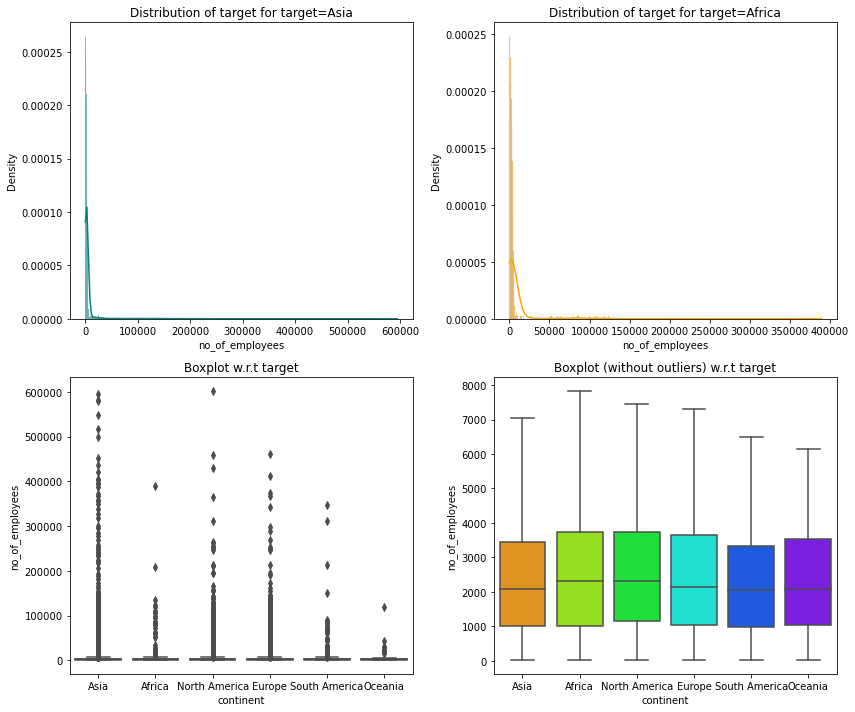

```python
distribution_plot_wrt_target(
    data, "no_of_employees", "continent"
)  # find distribution of number of employees and continent
```

#### Distribution of the prevailing wage across the different continents

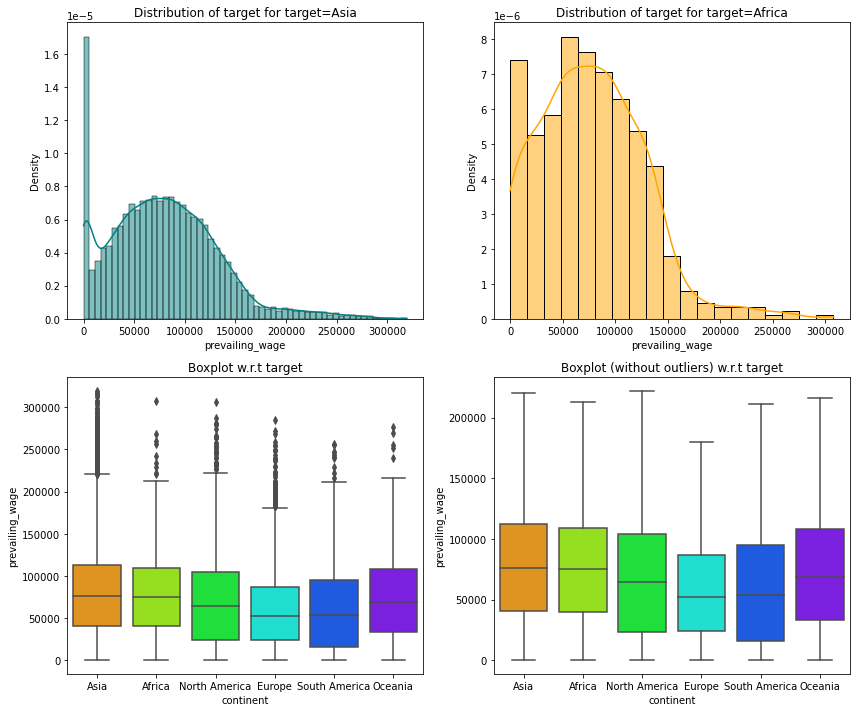

```python
distribution_plot_wrt_target(
    data, "prevailing_wage", "continent"
)  # find distribution of prevailing wage and continent
```

#### Distribution of the unit of wage used by employees from the different continents

```
unit_of_wage   Hour  Month  Week   Year    All
continent
All            2157     89   272  22962  25480
Asia           1311     58   154  15338  16861
North America   495     17    75   2705   3292
Europe          140      7    17   3568   3732
Africa           36      3     8    504    551
Oceania          18      2     4    168    192
South America   157      2    14    679    852
------------------------------------------------------------------------------------------------------------------------
```

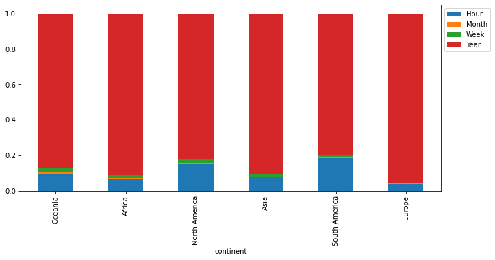

```python
stacked_barplot(
    data, "continent", "unit_of_wage"
)  # distribution of continent and unit of wage
```

- The european employees are the most paid in the yearly unit wage category with the asians and africans trailing closely.

#### Distribution of education of employee and need for job training

```
requires_job_training      N     Y    All
education_of_employee
All                    22525  2955  25480
Bachelor's              8971  1263  10234
Master's                8786   848   9634
High School             2990   430   3420
Doctorate               1778   414   2192
------------------------------------------------------------------------------------------------------------------------
```

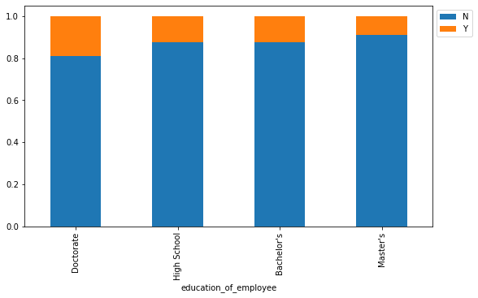

```python
stacked_barplot(
    data, "education_of_employee", "requires_job_training"
)  # distribution of continent and unit of wage
```

#### Distribution of education and region of employment

```
region_of_employment   Island  Midwest  Northeast  South  West    All
education_of_employee
All                       375     4307       7195   7017  6586  25480
Master's                  161     2000       2760   2551  2162   9634
Bachelor's                129     1315       2874   2991  2925  10234
High School                60      736        905    934   785   3420
Doctorate                  25      256        656    541   714   2192
------------------------------------------------------------------------------------------------------------------------
```

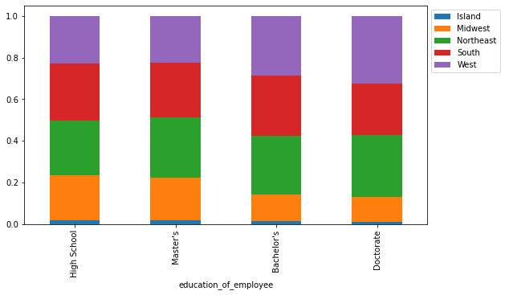

```python
stacked_barplot(
    data, "education_of_employee", "region_of_employment"
)  # distribution of education and region of employment
```

#### Distribution of education and prevailing wage

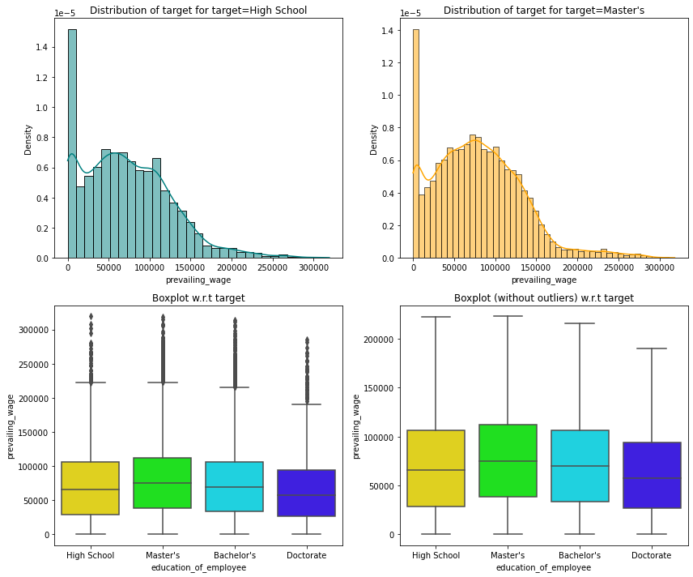

```python
distribution_plot_wrt_target(
    data, "prevailing_wage", "education_of_employee"
)  # find distribution of prevailing wage and education level
```

- Employees with a masters education have the highest mean prevailing wage. Doctorate degree holders have the least mean prevailing wage but this could be due to the relative count of employees in that category.

#### Distribution of Education and Job status

```
full_time_position        N      Y    All
education_of_employee
All                    2707  22773  25480
Master's               1738   7896   9634
Bachelor's              683   9551  10234
High School             206   3214   3420
Doctorate                80   2112   2192
------------------------------------------------------------------------------------------------------------------------
```

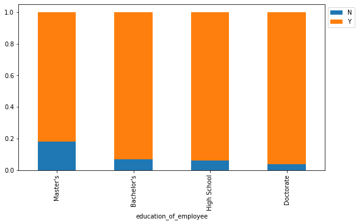

```python
stacked_barplot(
    data, "education_of_employee", "full_time_position"
)  # distribution of education and region of employment
```

#### Distribution of employees and job experience status

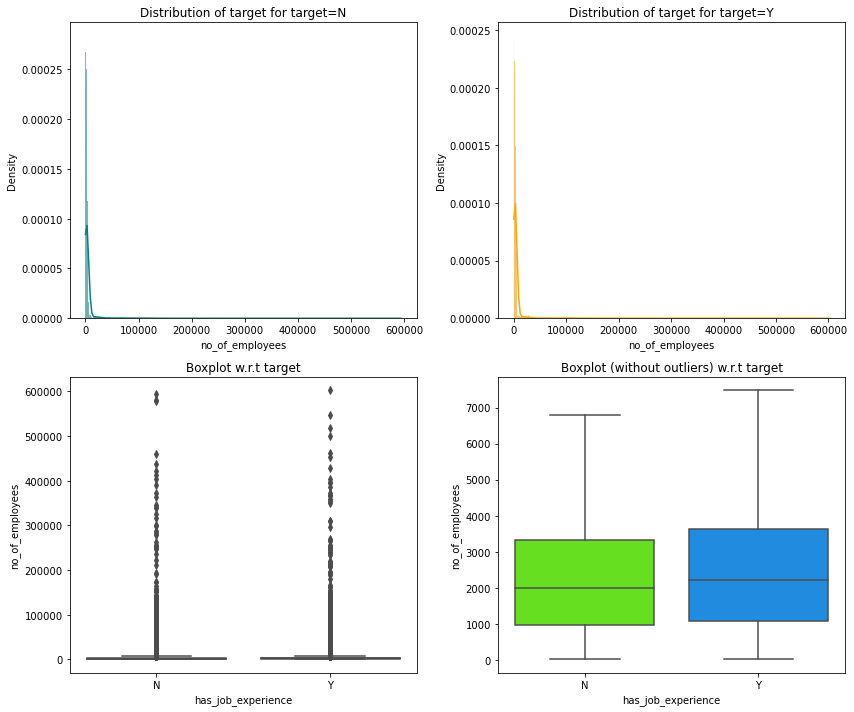

```python
distribution_plot_wrt_target(
    data, "no_of_employees", "has_job_experience"
)  # find distribution of prevailing wage and education level
```

- The mean number of employees for those with job experience are more than those who do not have job experience.

#### Distribution of prevailing wage and job experience status

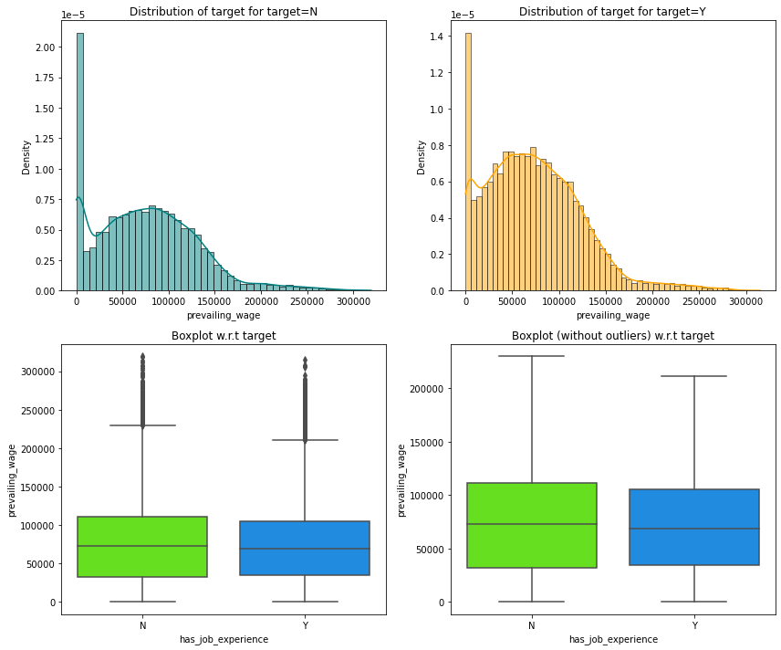

```python
distribution_plot_wrt_target(
    data, "prevailing_wage", "has_job_experience"
)  # find distribution of prevailing wage and job experience
```

- The mean salary for both categories are similar indicating a fair distribution of wages for both categories.

#### Job experience status and full time job

```
full_time_position     N      Y    All
has_job_experience
All                 2707  22773  25480
Y                   1410  13392  14802
N                   1297   9381  10678
------------------------------------------------------------------------------------------------------------------------
```

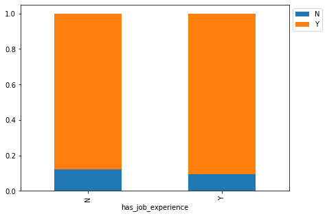

```python
stacked_barplot(
    data, "has_job_experience", "full_time_position"
)  # distribution of education and region of employment
```

- There are slightly more employees with full time jobs with some job experience than those in the counter category.

#### Number of Employees and Region of Employment

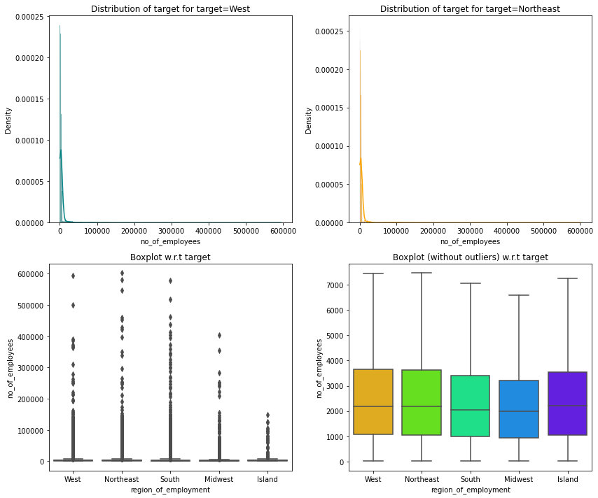

```python
distribution_plot_wrt_target(
    data, "no_of_employees", "region_of_employment"
)  # find distribution of prevailing wage and job experience
```

- The Island has the mean number of employees ; closely trailed by the West and NorthEast.

#### Prevailing Wage and Case Status

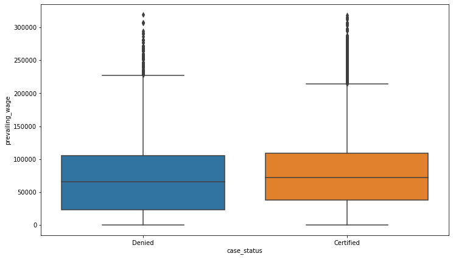

```python
plt.figure(figsize=(12, 7))  # size configuration
sns.boxplot(data=data, x="case_status", y="prevailing_wage")  # create boxplot
```

- Employees who have a certified visa earn have a higher mean prevailing wage than those denied.

#### Full Time Position and Case Status

```
case_status         Certified  Denied    All
full_time_position
All                     17018    8462  25480
Y                       15163    7610  22773
N                        1855     852   2707
------------------------------------------------------------------------------------------------------------------------
```

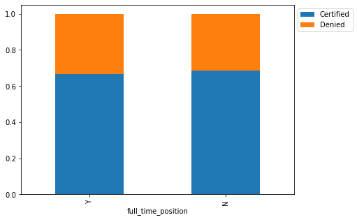

```python
stacked_barplot(
    data, "full_time_position", "case_status"
)  # distribution of education and region of employment
```

- There is a similar ratio for both category of employees.

#### Full time position and Unit of Wage

```
unit_of_wage        Hour  Month  Week   Year    All
full_time_position
All                 2157     89   272  22962  25480
Y                   2138     84   262  20289  22773
N                     19      5    10   2673   2707
------------------------------------------------------------------------------------------------------------------------
```

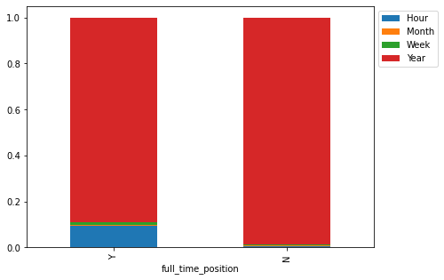

```python
stacked_barplot(
    data, "full_time_position", "unit_of_wage"
)  # distribution of education and region of employment
```

- Employees who do not have a full time job mostly earn a yearly wage.
- For employees who have a full time job, those who earn a yearly wage occupy the majority.

#### Requires Job Training and Case Status

```
case_status            Certified  Denied    All
requires_job_training
All                        17018    8462  25480
N                          15012    7513  22525
Y                           2006     949   2955
------------------------------------------------------------------------------------------------------------------------
```

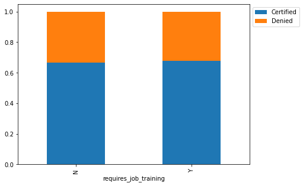

```python
stacked_barplot(
    data, "requires_job_training", "case_status"
)  # distribution of education and region of employment
```

- There is a similar ratio for both categories

### Data Preprocessing

#### Outlier check

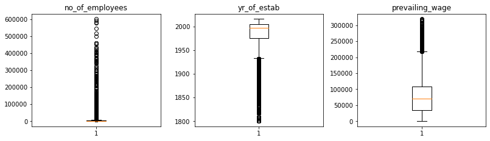

```python
# outlier detection using boxplot
numeric_columns = data.select_dtypes(include=np.number).columns.tolist()


plt.figure(figsize=(15, 12))

for i, variable in enumerate(numeric_columns):
    plt.subplot(4, 4, i + 1)
    plt.boxplot(data[variable], whis=1.5)
    plt.tight_layout()
    plt.title(variable)

# create boxplots for all the numeric columns
plt.show()
```

- The number of employees is the category with the heaviest presence of outliers.

### Data Preparation for Modeling

```python
# encode the categorical variables
data["case_status"] = data["case_status"].apply(lambda x: 1 if x == "Certified" else 0)

X = data.drop("case_status", axis=1)  # drop case status from the data
Y = data["case_status"]


X = pd.get_dummies(X, drop_first=True)  # create dummies for X

# Split data in train and test sets
X_train, X_test, y_train, y_test = train_test_split(
    X, Y, test_size=0.30, random_state=1, stratify=Y
)  # split the data into train and test in the ratio 70:30
```

```python
print("Shape of Training set : ", X_train.shape)
print("Shape of test set : ", X_test.shape)
print("Percentage of classes in training set:")
print(y_train.value_counts(normalize=True))
print("Percentage of classes in test set:")
print(y_test.value_counts(normalize=True))
```

```
Shape of Training set :  (17836, 21)
Shape of test set :  (7644, 21)
Percentage of classes in training set:
1    0.667919
0    0.332081
Name: case_status, dtype: float64
Percentage of classes in test set:
1    0.667844
0    0.332156
Name: case_status, dtype: float64
```

### Model Evaluation Criterion

### Model can make wrong predictions as:

1. Model predicts that the visa application will get certified but in reality, the visa application should get denied.
2. Model predicts that the visa application will not get certified but in reality, the visa application should get certified.

### Which case is more important?

- Both the cases are important as:
- If a visa is certified when it had to be denied a wrong employee will get the job position while US citizens will miss the opportunity to work on that position.
- If a visa is denied when it had to be certified the U.S. will lose a suitable human resource that can contribute to the economy.

### How to reduce the losses?

- `F1 Score` can be used a the metric for evaluation of the model, greater the F1 score higher are the chances of minimizing False Negatives and False Positives.
- We will use balanced class weights so that model focuses equally on both classes.

```python
# function to compute model performance of a classification model built using sklearn


def model_performance_classification_sklearn(model, predictors, target):
    """
    Function to compute different metrics to check classification model performance

    model: classifier
    predictors: independent variables
    target: dependent variable
    """

    # predicting using the independent variables
    pred = model.predict(predictors)

    acc = accuracy_score(target, pred)  # to compute Accuracy
    recall = recall_score(target, pred)  # to compute Recall
    precision = precision_score(target, pred)  # to compute Precision
    f1 = f1_score(target, pred)  # to compute F1-score

    # creating a dataframe of metrics
    df_perf = pd.DataFrame(
        {"Accuracy": acc, "Recall": recall, "Precision": precision, "F1": f1,},
        index=[0],
    )

    return df_perf
```

```python
# function to create confusion matrix


def confusion_matrix_sklearn(model, predictors, target):
    """
    To plot the confusion_matrix with percentages

    model: classifier
    predictors: independent variables
    target: dependent variable
    """
    y_pred = model.predict(predictors)
    cm = confusion_matrix(target, y_pred)
    labels = np.asarray(
        [
            ["{0:0.0f}".format(item) + "\n{0:.2%}".format(item / cm.flatten().sum())]
            for item in cm.flatten()
        ]
    ).reshape(2, 2)

    plt.figure(figsize=(6, 4))
    sns.heatmap(cm, annot=labels, fmt="")
    plt.ylabel("True label")
    plt.xlabel("Predicted label")
```

## Decision Tree - Model Building and Hyperparameter Tuning

### Decision Tree Model

```python
model = DecisionTreeClassifier(
    random_state=1
)  # define decision tree classifier with random state = 1
model.fit(X_train, y_train)  # decision tree classifier on the train data
```

```
DecisionTreeClassifier(random_state=1)
```

#### Model performance on training set

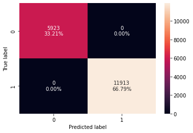

```python
confusion_matrix_sklearn(
    model, X_train, y_train
)  # create confusion matrix for train data
```

```python
decision_tree_perf_train = model_performance_classification_sklearn(
    model, X_train, y_train
)  ## performance on train data
decision_tree_perf_train
```

|  | Accuracy | Recall | Precision | F1 |
| --- | --- | --- | --- | --- |
| 0 | 1.0 | 1.0 | 1.0 | 1.0 |

- The model perfectly classifies all the data points on the train data.

#### Model performance on test data

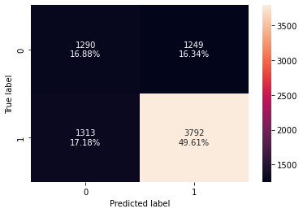

```python
confusion_matrix_sklearn(model, X_test, y_test)  # create confusion matrix for test data
```

```python
decision_tree_perf_test = model_performance_classification_sklearn(
    model, X_test, y_test
)  ## performance on train data
decision_tree_perf_test  # create confusion matrix for test data
```

|  | Accuracy | Recall | Precision | F1 |
| --- | --- | --- | --- | --- |
| 0 | 0.664835 | 0.742801 | 0.752232 | 0.747487 |

- The model is not working so well on the test data indicating some overfitting on the test data.

### Hyperparameter Tuning - Decision Tree

```python
# Choose the type of classifier.
dtree_estimator = DecisionTreeClassifier(class_weight="balanced", random_state=1)

# Grid of parameters to choose from
parameters = {
    "max_depth": np.arange(5, 16, 5),
    "min_samples_leaf": [3, 5, 7],
    "max_leaf_nodes": [2, 5],
    "min_impurity_decrease": [0.0001, 0.001],
}

# Type of scoring used to compare parameter combinations
scorer = metrics.make_scorer(metrics.f1_score)

# Run the grid search
grid_obj = GridSearchCV(
    dtree_estimator, parameters, scoring=scorer, n_jobs=-1
)  # run grid search with n_jobs = -1

grid_obj = grid_obj.fit(X_train, y_train)  # fit the grid_obj on the train data

# Set the clf to the best combination of parameters
dtree_estimator = grid_obj.best_estimator_

# Fit the best algorithm to the data.
dtree_estimator.fit(X_train, y_train)
```

```
DecisionTreeClassifier(class_weight='balanced', max_depth=5, max_leaf_nodes=2,
                       min_impurity_decrease=0.0001, min_samples_leaf=3,
                       random_state=1)
```

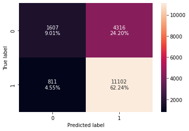

```python
confusion_matrix_sklearn(
    dtree_estimator, X_train, y_train
)  # create confusion matrix for train data on tuned estimator
```

```python
dtree_estimator_model_train_perf = model_performance_classification_sklearn(
    dtree_estimator, X_train, y_train
)  # performance for train data on tuned estimator
dtree_estimator_model_train_perf
```

|  | Accuracy | Recall | Precision | F1 |
| --- | --- | --- | --- | --- |
| 0 | 0.712548 | 0.931923 | 0.720067 | 0.812411 |

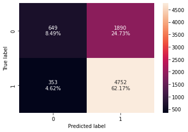

```python
confusion_matrix_sklearn(
    dtree_estimator, X_test, y_test
)  # create confusion matrix for test data on tuned estimator
```

```python
dtree_estimator_model_test_perf = model_performance_classification_sklearn(
    dtree_estimator, X_test, y_test
)  # performance for train data on tuned estimator
dtree_estimator_model_test_perf
```

|  | Accuracy | Recall | Precision | F1 |
| --- | --- | --- | --- | --- |
| 0 | 0.706567 | 0.930852 | 0.715447 | 0.809058 |

- The model is giving more generalized results now on both the train and test data sets as seen in the F1 score values.
- The model shows similar results for the other metrics as well.

### Bagging - Model Building and Hyperparameter Tuning

#### Bagging Classifier

```python
bagging_classifier = BaggingClassifier(
    random_state=1
)  # define bagging classifier with random state = 1
bagging_classifier.fit(X_train, y_train)  # fit bagging classifier on the train data
```

```
BaggingClassifier(random_state=1)
```

#### Checking model performance on training set

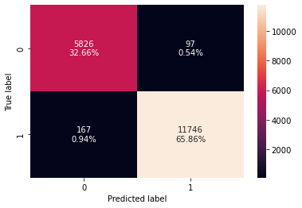

```python
confusion_matrix_sklearn(
    bagging_classifier, X_train, y_train
)  # create confusion matrix for train data
```

```python
bagging_classifier_model_train_perf = model_performance_classification_sklearn(
    bagging_classifier, X_train, y_train
)  # performance on train data
bagging_classifier_model_train_perf
```

|  | Accuracy | Recall | Precision | F1 |
| --- | --- | --- | --- | --- |
| 0 | 0.985198 | 0.985982 | 0.99181 | 0.988887 |

#### Checking model performance on test data

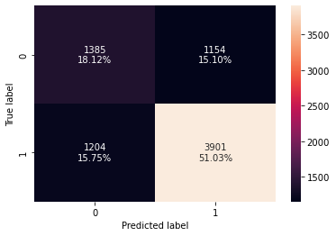

```python
confusion_matrix_sklearn(
    bagging_classifier, X_test, y_test
)  # create confusion matrix for test data
```

```python
bagging_classifier_model_test_perf = model_performance_classification_sklearn(
    bagging_classifier, X_test, y_test
)  # performance on test data
bagging_classifier_model_test_perf
```

|  | Accuracy | Recall | Precision | F1 |
| --- | --- | --- | --- | --- |
| 0 | 0.691523 | 0.764153 | 0.771711 | 0.767913 |

- The bagging model performs well on the train data but overfits on the test data as seen in the disparity in F1 scores.

#### Hyperparameter tuning the Bagging Classifier

```python
# Choose the type of classifier.
bagging_estimator_tuned = BaggingClassifier(random_state=1)

# Grid of parameters to choose from
parameters = {
    "max_samples": [0.7, 0.9],
    "max_features": [0.7, 0.9],
    "n_estimators": np.arange(90, 111, 10),
}

# Type of scoring used to compare parameter combinations
acc_scorer = metrics.make_scorer(metrics.f1_score)

# Run the grid search
grid_obj = GridSearchCV(
    bagging_estimator_tuned, parameters, scoring=acc_scorer, cv=5
)  # run grid search with cv = 5
grid_obj = grid_obj.fit(X_train, y_train)  # fit the grid_obj on train data

# Set the clf to the best combination of parameters
bagging_estimator_tuned = grid_obj.best_estimator_

# Fit the best algorithm to the data.
bagging_estimator_tuned.fit(X_train, y_train)
```

```
BaggingClassifier(max_features=0.7, max_samples=0.7, n_estimators=100,
                  random_state=1)
```

#### Checking model performance on training data

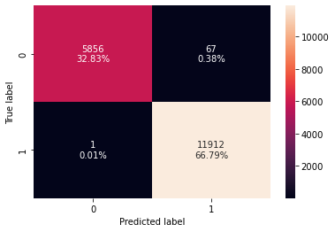

```python
confusion_matrix_sklearn(
    bagging_estimator_tuned, X_train, y_train
)  # create confusion matrix for train data on tuned estimator
```

```python
bagging_estimator_tuned_model_train_perf = model_performance_classification_sklearn(
    bagging_estimator_tuned, X_train, y_train
)  # performance on train data
bagging_estimator_tuned_model_train_perf
```

|  | Accuracy | Recall | Precision | F1 |
| --- | --- | --- | --- | --- |
| 0 | 0.996187 | 0.999916 | 0.994407 | 0.997154 |

#### Checking model performance on testing data

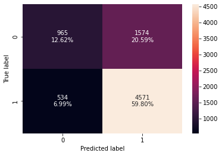

```python
confusion_matrix_sklearn(
    bagging_estimator_tuned, X_test, y_test
)  # create confusion matrix for test data on tuned estimator
```

```python
bagging_estimator_tuned_model_test_perf = model_performance_classification_sklearn(
    bagging_estimator_tuned, X_test, y_test
)  # performance on test data
bagging_estimator_tuned_model_test_perf
```

|  | Accuracy | Recall | Precision | F1 |
| --- | --- | --- | --- | --- |
| 0 | 0.724228 | 0.895397 | 0.743857 | 0.812622 |

- Even though the F1 score has improved on the test data, there is still significant disparity between the two values indicating that the classifier is overfitting on the test data.
- We will try other techniques to obtain a better classifier.

### Random Forest

```python
# Fitting the model
rf_estimator = RandomForestClassifier(
    random_state=1, class_weight="balanced"
)  # define random forest with random state = 1 and class_weight = balanced
rf_estimator.fit(X_train, y_train)  # fit random forest on the train data
```

```
RandomForestClassifier(class_weight='balanced', random_state=1)
```

#### Checking performance on train data

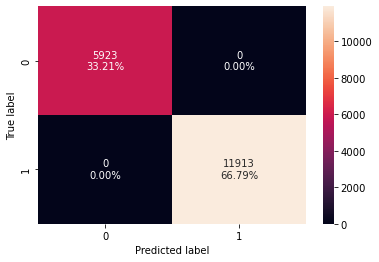

```python
confusion_matrix_sklearn(
    rf_estimator, X_train, y_train
)  # create confusion matrix for train data
```

```python
# Calculating different metrics
rf_estimator_model_train_perf = model_performance_classification_sklearn(
    rf_estimator, X_train, y_train
)  # performance on train data
rf_estimator_model_train_perf
```

|  | Accuracy | Recall | Precision | F1 |
| --- | --- | --- | --- | --- |
| 0 | 1.0 | 1.0 | 1.0 | 1.0 |

#### Checking performance on test data

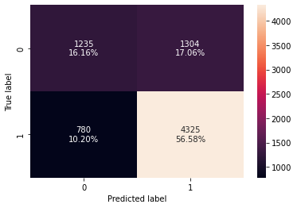

```python
confusion_matrix_sklearn(
    rf_estimator, X_test, y_test
)  # create confusion matrix for test data
```

```python
# Calculating different metrics
rf_estimator_model_test_perf = model_performance_classification_sklearn(
    rf_estimator, X_test, y_test
)  # performance on test data
rf_estimator_model_test_perf
```

|  | Accuracy | Recall | Precision | F1 |
| --- | --- | --- | --- | --- |
| 0 | 0.727368 | 0.847209 | 0.768343 | 0.805851 |

- The model performs well on the train data but overfits on the test data as seen in their F1 scores.

### Hyperparameter Tuning - Random Forest

```python
# Choose the type of classifier.
rf_tuned = RandomForestClassifier(random_state=1, oob_score=True, bootstrap=True)

parameters = {
    "max_depth": list(np.arange(5, 15, 5)),
    "max_features": ["sqrt", "log2"],
    "min_samples_split": [5, 7],
    "n_estimators": np.arange(15, 26, 5),
}

# Type of scoring used to compare parameter combinations
acc_scorer = metrics.make_scorer(metrics.f1_score)

# Run the grid search
grid_obj = GridSearchCV(
    rf_tuned, parameters, scoring=acc_scorer, cv=5, n_jobs=-1
)  # run grid search with cv = 5 and n_jobs = -1
grid_obj = grid_obj.fit(X_train, y_train)  # fit the grid_obj on the train data

# Set the clf to the best combination of parameters
rf_tuned = grid_obj.best_estimator_

# Fit the best algorithm to the data.
rf_tuned.fit(X_train, y_train)
```

```
RandomForestClassifier(max_depth=10, max_features='sqrt', min_samples_split=7,
                       n_estimators=20, oob_score=True, random_state=1)
```

#### Checking performance on train data

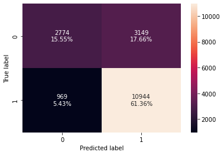

```python
confusion_matrix_sklearn(
    rf_tuned, X_train, y_train
)  # create confusion matrix for train data on tuned estimator
```

```python
rf_tuned_model_train_perf = model_performance_classification_sklearn(
    rf_tuned, X_train, y_train
)  # check performance for train data on tuned estimator
rf_tuned_model_train_perf
```

|  | Accuracy | Recall | Precision | F1 |
| --- | --- | --- | --- | --- |
| 0 | 0.769119 | 0.91866 | 0.776556 | 0.841652 |

#### Checking model performance on test set

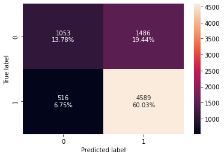

```python
confusion_matrix_sklearn(
    rf_tuned, X_test, y_test
)  # create confusion matrix for test data on tuned estimator
```

```python
rf_tuned_model_test_perf = model_performance_classification_sklearn(
    rf_tuned, X_test, y_test
)  # check performance for test data on tuned estimator
rf_tuned_model_test_perf
```

|  | Accuracy | Recall | Precision | F1 |
| --- | --- | --- | --- | --- |
| 0 | 0.738095 | 0.898923 | 0.755391 | 0.82093 |

- The tuned random forest classifier is doing better on the test data than the random classifier with default parameters.
- Even though the F1 score has improved on the test data for the tuned random forest, it is slightly lower than the F1 score on the train data indicating some overfitting.

### Boosting - Model Building and Hyperparameter Tuning

#### AdaBoost Classifier

```python
ab_classifier = AdaBoostClassifier(
    random_state=1
)  #  define AdaBoost Classifier with random state = 1
ab_classifier.fit(X_train, y_train)  #  fit AdaBoost Classifier on the train data
```

```
AdaBoostClassifier(random_state=1)
```

#### Checking model performance on training set

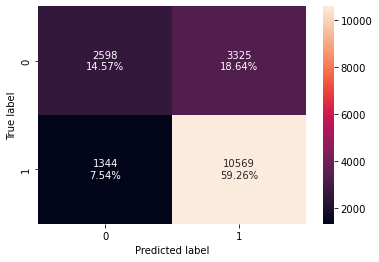

```python
confusion_matrix_sklearn(
    ab_classifier, X_train, y_train
)  # create confusion matrix for train data
```

```python
ab_classifier_model_train_perf = model_performance_classification_sklearn(
    ab_classifier, X_train, y_train
)  # performance for train data
ab_classifier_model_train_perf
```

|  | Accuracy | Recall | Precision | F1 |
| --- | --- | --- | --- | --- |
| 0 | 0.738226 | 0.887182 | 0.760688 | 0.81908 |

#### Checking model performance on test set

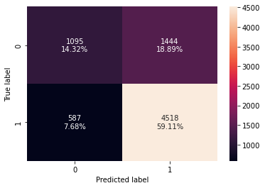

```python
confusion_matrix_sklearn(
    ab_classifier, X_test, y_test
)  # create confusion matrix for test data
```

```python
ab_classifier_model_test_perf = model_performance_classification_sklearn(
    ab_classifier, X_test, y_test
)  # performance for test data
ab_classifier_model_test_perf
```

|  | Accuracy | Recall | Precision | F1 |
| --- | --- | --- | --- | --- |
| 0 | 0.734301 | 0.885015 | 0.757799 | 0.816481 |

- The model performs well on both the train and test data as indicated in their F1 scores.

### Hyperparameter Tuning - AdaBoost Classifier

```python
# Choose the type of classifier.
abc_tuned = AdaBoostClassifier(random_state=1)

# Grid of parameters to choose from
parameters = {
    # Let's try different max_depth for base_estimator
    "base_estimator": [
        DecisionTreeClassifier(max_depth=1, class_weight="balanced", random_state=1),
        DecisionTreeClassifier(max_depth=2, class_weight="balanced", random_state=1),
    ],
    "n_estimators": np.arange(80, 101, 10),
    "learning_rate": np.arange(0.1, 0.4, 0.1),
}

# Type of scoring used to compare parameter  combinations
acc_scorer = metrics.make_scorer(metrics.f1_score)

# Run the grid search
grid_obj = GridSearchCV(
    abc_tuned, parameters, scoring=acc_scorer, cv=5
)  # run grid search with cv = 5
grid_obj = grid_obj.fit(X_train, y_train)  # fit the grid_obj on train data

# Set the clf to the best combination of parameters
abc_tuned = grid_obj.best_estimator_

# Fit the best algorithm to the data.
abc_tuned.fit(X_train, y_train)
```

```
AdaBoostClassifier(base_estimator=DecisionTreeClassifier(class_weight='balanced',
                                                         max_depth=1,
                                                         random_state=1),
                   learning_rate=0.1, n_estimators=100, random_state=1)
```

#### Checking model performance on training set

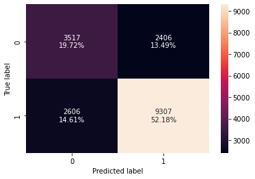

```python
confusion_matrix_sklearn(
    abc_tuned, X_train, y_train
)  # create confusion matrix for train data on tuned estimator
```

```python
abc_tuned_model_train_perf = model_performance_classification_sklearn(
    abc_tuned, X_train, y_train
)  # performance for test data on tuned estimator
abc_tuned_model_train_perf
```

|  | Accuracy | Recall | Precision | F1 |
| --- | --- | --- | --- | --- |
| 0 | 0.718995 | 0.781247 | 0.794587 | 0.787861 |

#### Checking model performance on test set

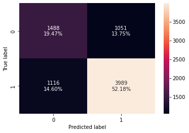

```python
confusion_matrix_sklearn(
    abc_tuned, X_test, y_test
)  # create confusion matrix for test data on tuned estimator
```

```python
abc_tuned_model_test_perf = model_performance_classification_sklearn(
    abc_tuned, X_test, y_test
)  # test data on tuned estimator
abc_tuned_model_test_perf
```

|  | Accuracy | Recall | Precision | F1 |
| --- | --- | --- | --- | --- |
| 0 | 0.71651 | 0.781391 | 0.791468 | 0.786397 |

- Although the F1 score has reduced after tuning the hyperparameters, the model still performs well on both the train and test data as indicated in their similar F1 scores.

### Gradient Boosting Classifier

```python
gb_classifier = GradientBoostingClassifier(
    random_state=1
)  # define Gradient Boosting Classifier with random state = 1
gb_classifier.fit(
    X_train, y_train
)  ## fit Gradient Boosting Classifier on the train data
```

```
GradientBoostingClassifier(random_state=1)
```

#### Checking model performance on training set

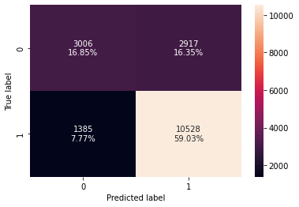

```python
# confusion matrix of the classifier's performance on the train data
confusion_matrix_sklearn(gb_classifier, X_train, y_train)
```

```python
gb_classifier_model_train_perf = model_performance_classification_sklearn(
    gb_classifier, X_train, y_train
)  ## performance on train data
gb_classifier_model_train_perf
```

|  | Accuracy | Recall | Precision | F1 |
| --- | --- | --- | --- | --- |
| 0 | 0.758802 | 0.88374 | 0.783042 | 0.830349 |

#### Checking model performance on test set

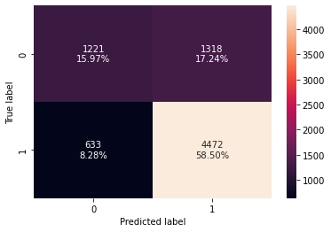

```python
# confusion matrix of the classifier's performance on the test data
confusion_matrix_sklearn(gb_classifier, X_test, y_test)
```

```python
gb_classifier_model_test_perf = model_performance_classification_sklearn(
    gb_classifier, X_test, y_test
)  # performance for test data
gb_classifier_model_test_perf
```

|  | Accuracy | Recall | Precision | F1 |
| --- | --- | --- | --- | --- |
| 0 | 0.744767 | 0.876004 | 0.772366 | 0.820927 |

- The model performs well on the train and test data. The disparity between their metric values is insignificant.

### Hyperparameter Tuning - Gradient Boosting Classifier

```python
# Choose the type of classifier.
gbc_tuned = GradientBoostingClassifier(
    init=AdaBoostClassifier(random_state=1), random_state=1
)

# Grid of parameters to choose from
parameters = {
    "n_estimators": [200, 250],
    "subsample": [0.9, 1],
    "max_features": [0.8, 0.9],
    "learning_rate": np.arange(0.1, 0.21, 0.1),
}

# Type of scoring used to compare parameter combinations
acc_scorer = metrics.make_scorer(metrics.f1_score)

# Run the grid search
grid_obj = GridSearchCV(
    gbc_tuned, parameters, scoring=acc_scorer, cv=5
)  ##  run grid search with cv = 5
grid_obj = grid_obj.fit(X_train, y_train)  ##  fit the grid_obj on train data

# Set the clf to the best combination of parameters
gbc_tuned = grid_obj.best_estimator_

# Fit the best algorithm to the data.
gbc_tuned.fit(X_train, y_train)
```

```
GradientBoostingClassifier(init=AdaBoostClassifier(random_state=1),
                           max_features=0.8, n_estimators=200, random_state=1,
                           subsample=1)
```

#### Checking model performance on training set

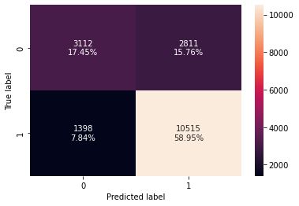

```python
confusion_matrix_sklearn(
    gbc_tuned, X_train, y_train
)  # create confusion matrix for train data on tuned estimator
```

```python
gbc_tuned_model_train_perf = model_performance_classification_sklearn(
    gbc_tuned, X_train, y_train
)  # check performance for train data on tuned estimator
gbc_tuned_model_train_perf
```

|  | Accuracy | Recall | Precision | F1 |
| --- | --- | --- | --- | --- |
| 0 | 0.764017 | 0.882649 | 0.789059 | 0.833234 |

#### Checking model performance on test set

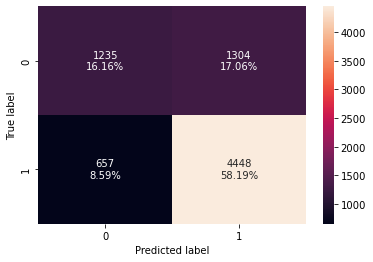

```python
confusion_matrix_sklearn(
    gbc_tuned, X_test, y_test
)  # create confusion matrix for test data on tuned estimator
```

```python
gbc_tuned_model_test_perf = model_performance_classification_sklearn(
    gbc_tuned, X_test, y_test
)  # check performance for test data on tuned estimator
gbc_tuned_model_test_perf
```

|  | Accuracy | Recall | Precision | F1 |
| --- | --- | --- | --- | --- |
| 0 | 0.743459 | 0.871303 | 0.773296 | 0.819379 |

- The F1 score on the test data reduced indicating that model performs well on the train data but not as well on the test data.